# Project 4 (1)-Copy1

## Project 4

**Load bike-sales CSV File into df dataframe and display the first 5 rows**

```python
import pandas as pd
df = pd.read_csv('bike-sales.csv')
df.head()
```

|  | Date | Customer_Age | Age_Group | Customer_Gender | Country | State | Product_Category | Sub_Category | Product | Order_Quantity | Unit_Cost | Unit_Price | Profit | Cost | Revenue |
| --- | --- | --- | --- | --- | --- | --- | --- | --- | --- | --- | --- | --- | --- | --- | --- |
| 0 | 11/26/2013 | 19 | Youth (<25) | M | Canada | British Columbia | Accessories | Bike Racks | Hitch Rack - 4-Bike | 8 | 45 | 120 | 590 | 360 | 950 |
| 1 | 11/26/2015 | 19 | Youth (<25) | M | Canada | British Columbia | Accessories | Bike Racks | Hitch Rack - 4-Bike | 8 | 45 | 120 | 590 | 360 | 950 |
| 2 | 3/23/2014 | 49 | Adults (35-64) | M | Australia | New South Wales | Accessories | Bike Racks | Hitch Rack - 4-Bike | 23 | 45 | 120 | 1366 | 1035 | 2401 |
| 3 | 3/23/2016 | 49 | Adults (35-64) | M | Australia | New South Wales | Accessories | Bike Racks | Hitch Rack - 4-Bike | 20 | 45 | 120 | 1188 | 900 | 2088 |
| 4 | 5/15/2014 | 47 | Adults (35-64) | F | Australia | New South Wales | Accessories | Bike Racks | Hitch Rack - 4-Bike | 4 | 45 | 120 | 238 | 180 | 418 |

```python
df1 = df
```

**Import required libraries for visualization (matplotlib and seaborn)**

```python
import matplotlib.pyplot as plt
import seaborn as sns

# important: ensures the visualizations will be in the Notebook
%matplotlib inline
```

**Question 1:**

**Explore the dataframe: the shape of the df1, the list of columns, check if there is any missing values**

```python
df1.shape
```

```
(113036, 15)
```

```python
df1.columns
```

```
Index(['Date', 'Customer_Age', 'Age_Group', 'Customer_Gender', 'Country',
       'State', 'Product_Category', 'Sub_Category', 'Product',
       'Order_Quantity', 'Unit_Cost', 'Unit_Price', 'Profit', 'Cost',
       'Revenue'],
      dtype='object')
```

```python
df1.isnull().sum()
```

```
Date                0
Customer_Age        0
Age_Group           0
Customer_Gender     0
Country             0
State               0
Product_Category    0
Sub_Category        0
Product             0
Order_Quantity      0
Unit_Cost           0
Unit_Price          0
Profit              0
Cost                0
Revenue             0
dtype: int64
```

**Question 2:**

**Generate the descriptive statistics to show count, mean, std, min, max, and etc. of numeric columns in the df1 dataframe**

```python
df1.describe().transpose()
```

|  | count | mean | std | min | 25% | 50% | 75% | max |
| --- | --- | --- | --- | --- | --- | --- | --- | --- |
| Customer_Age | 113036.0 | 35.919212 | 11.021936 | 17.0 | 28.0 | 35.0 | 43.0 | 87.0 |
| Order_Quantity | 113036.0 | 11.901660 | 9.561857 | 1.0 | 2.0 | 10.0 | 20.0 | 32.0 |
| Unit_Cost | 113036.0 | 267.296366 | 549.835483 | 1.0 | 2.0 | 9.0 | 42.0 | 2171.0 |
| Unit_Price | 113036.0 | 452.938427 | 922.071219 | 2.0 | 5.0 | 24.0 | 70.0 | 3578.0 |
| Profit | 113036.0 | 285.051665 | 453.887443 | -30.0 | 29.0 | 101.0 | 358.0 | 15096.0 |
| Cost | 113036.0 | 469.318695 | 884.866118 | 1.0 | 28.0 | 108.0 | 432.0 | 42978.0 |
| Revenue | 113036.0 | 754.370360 | 1309.094674 | 2.0 | 63.0 | 223.0 | 800.0 | 58074.0 |

**Question 3: Histogram**

**Use matplotlib to create the histogram of Customer_Age.**

- Use matplotlib (plt.) to add title: 'Customer_Age vs. Frequency of Customer_Age', add x label: 'Customer_Age' and y label: 'Frequency of Customer_Age'.

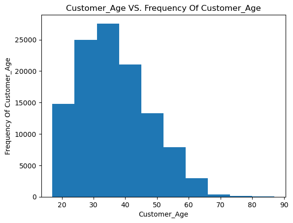

```python
plt.title('Customer_Age VS. Frequency Of Customer_Age')
plt.xlabel('Customer_Age')
plt.ylabel('Frequency Of Customer_Age')
plt.hist(df1['Customer_Age']) # we can use dot notation instead of bracket notation
plt.show()
```

**Question 4:**

**a. Use Seaborn to create a scatter plot of Cost vs. Revenue.**

- Put Cost on x-axis and Revenue on y-axis.
- Use Seaborn to add title. The title should be 'Cost vs. Revenue'.

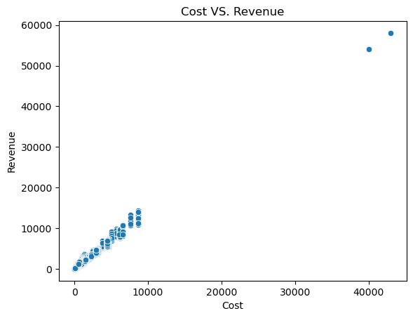

```python
sns.scatterplot(x=df1['Cost'], y=df1['Revenue']).set_title('Cost VS. Revenue')
```

**Question 5:**

**a. Use Seaborn to create a scatter plot with a regression line for Cost vs. Revenue to illustrate the strength of their relationship.**

- Put Cost on x-axis and Revenue on y-axis.
- Use Seaborn to add title. The title should be 'Cost vs. Revenue'.

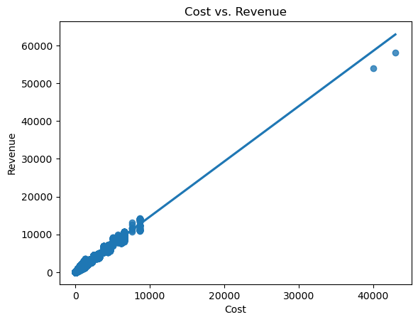

```python
sns.regplot(x=df1['Cost'], y=df1['Revenue']).set_title('Cost vs. Revenue')
```

**b. Based on the scatter plot with regression line, what kind of relationship (if any) do you observe between Cost and Revenue? Please describe any patterns or trends.** (whether they have positive or negative relationship and whether they have strong or weak relatonship?)

**The relationship between Cost and Revenue is strongly positive and linear. The increase in Cost consistently corresponds to an increase in Revenue, indicating a direct dependency.**

**Question 6:**

**Use Seaborn to create a scatter plot of Cost vs. Revenue.**

- Change the color of dots by 'Product_Category'.
- Put Cost on x-axis and Revenue on y-axis.
- Use Seaborn to add title. The title should be 'Cost vs. Revenue'.
- Create your own palette and name it palette1. Accessories should be yellow, Clothing should be blue, and Bikes should be purple.

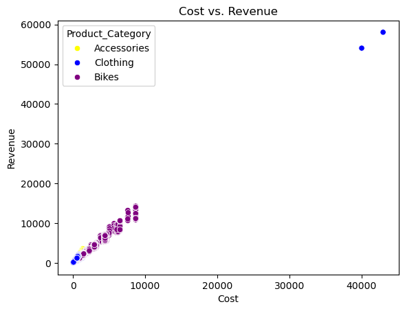

```python
palette1={'Accessories':'yellow','Clothing':'blue', 'Bikes':'purple'}
sns.scatterplot(x=df1['Cost'], y=df1['Revenue'], hue=df1['Product_Category'], palette=palette1).set_title('Cost vs. Revenue')
```

**Question 7:**

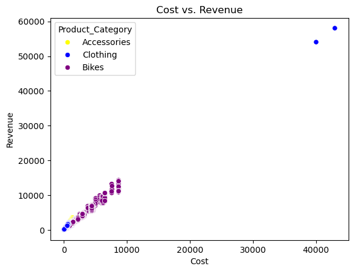

```python
palette2={'Accessories':'green','Clothing':'pink', 'Bikes':'black'}
sns.scatterplot(x=df1['Cost'], y=df1['Revenue'], hue=df1['Product_Category'], palette=palette1).set_title('Cost vs. Revenue')
```

**Question 8:**

**a. Use .plot() to create a bar chart to show the number of orders in each 'Country' .**

- Use matplotlib (plt.) to add title: 'Country vs. Number of Orders', add x label: 'Country' and y label: 'Number of Orders'.
- Add labels for each bar. The labels should show the number of orders with no decimal places
- Use seaborn's 'Set2' palette for the color of bars

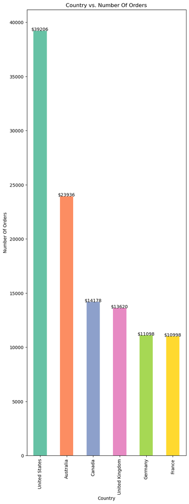

```python
# you can also specify which colors you want to use. e.g. color = ['red', 'gold', 'lightskyblue','blue','pink', 'darkgreen','yellow','grey']

plt.title('Country vs. Number Of Orders')
plt.xlabel('Country')
plt.ylabel('Number Of Orders')
ax=df1['Country'].value_counts()
ax.plot(kind='bar', color=sns.color_palette('Set2'))

for index, value in enumerate(ax):
    label = f'${value}'  # Format the label with 2 decimal places. I added $ sign to show $ for SOLDFOR
    plt.text(index, value,label,ha='center')

plt.subplots_adjust(top=3)
```

**Question 9:**

**Use .plot() to create a bar chart to show average profit in each 'Country' for 'Accessories' Product_Category.**

- Sort it in ascending order.
- Use seaborn's 'Set2' palette for the color.
- Use matplotlib (plt.) to add title:'Average profit in each Country for Accessories Product_Category', x label:'Country', and y label :'Average profit'.
- Add labels for each bar. The labels should show the average profit with 2 decimal places and should have $ sign.

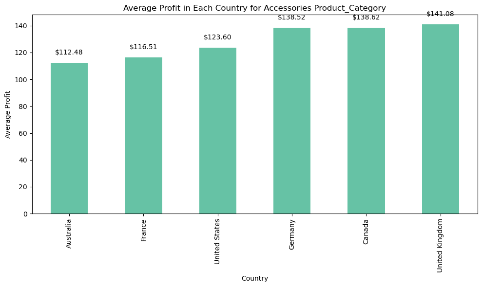

```python
accessories_df = df1[df1['Product_Category'] == 'Accessories']
avg_profit_per_country = accessories_df.groupby('Country')['Profit'].mean().sort_values()
sns.set_palette('Set2')
plt.figure(figsize=(10, 6))
ax = avg_profit_per_country.plot(kind='bar')
# Add title and labels
plt.title('Average Profit in Each Country for Accessories Product_Category')
plt.xlabel('Country')
plt.ylabel('Average Profit')
# Adding labels to each bar (showing average profit with 2 decimal places and a $ sign)
for i, v in enumerate(avg_profit_per_country):
    ax.text(i, v + 5, f'${v:.2f}', ha='center', va='bottom')
# Show the plot
plt.tight_layout()
plt.show()
```

**Question 10:**

**Use .plot() to create a pie chart to show the percentage of orders in each 'Country' for 'Accessories' Product_Category. Slices should have labels**.

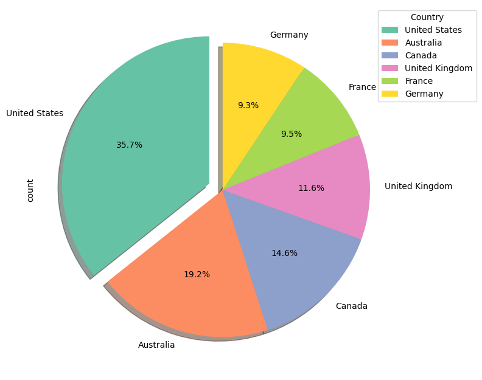

```python
explode_list = [0.1, 0, 0, 0, 0, 0] # ratio for each street with which to offset each wedge. Since we have 8 streets, I put 8 values in the list.
#plt.title('Percentage of orders in each Country for Accessories Product_Category')

# Filter data for 'Accessories' Product_Category
accessories_data = df1[df1['Product_Category'] == 'Accessories']

# Group by 'Country' to count the orders
df1 = accessories_data['Country'].value_counts()

# Plot the pie chart using the requested format
plt.figure(figsize=(8, 8))

df1.plot(kind='pie',
         autopct='%0.1f%%', # add percentages with 1 decimal place
         startangle=90,     # start angle at 90 degrees
         shadow=True,       # add shadow
         explode=explode_list # explode the 'United States' slice
         )

# Add a legend and ensure layout does not overlap
plt.legend(title="Country", loc="upper right", bbox_to_anchor=(1.2, 1))
plt.tight_layout()

# Show the plot
plt.show()
```